# Mgtr. Víctor Gauto

Mgtr. Víctor Gauto Ingeniero Químico

Fecha de nacimiento  
Correo electrónico  
Redes sociales  
Investigación  
Sitio web

28/feb/1989 (36 años)  
victor.gauto@ca.frre.utn.edu.ar  
/ vhgauto  
0000-0001-9960-8558 [Google Scholar](https://scholar.google.es/citations?user=nxCfD0AAAAAJ) [Research Gate](https://www.researchgate.net/profile/Victor_Gauto)  
https://vhgauto.github.io/  
Descargar versión

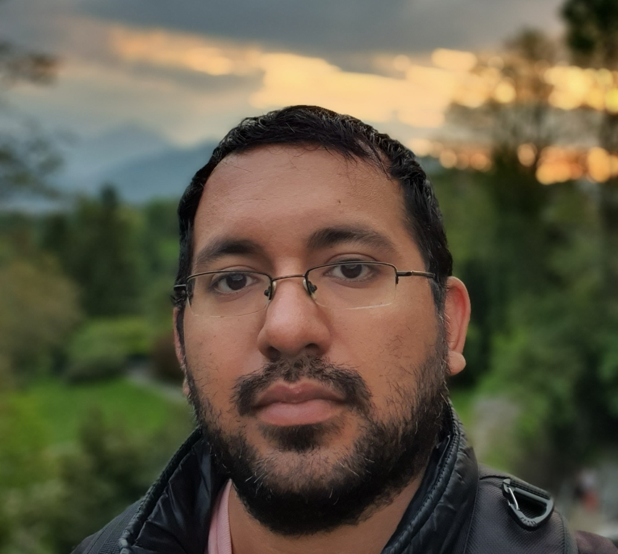

`data science` `data visualization` `GIS` `machine learning` `maps` `remote sensing` `Rstats` `water quality`

posición actual

Estudiante del Doctorado en Geomática y Sistemas Espaciales del [Instituto de Altos Estudios Espaciales Mario Gulich](https://ig.conae.unc.edu.ar/), dependiente de la [Comisión Nacional de Actividades Espaciales](https://www.argentina.gob.ar/ciencia/conae) y la [Universidad Nacional de Córdoba](https://www.unc.edu.ar/). Tema de tesis “Desarrollo de un modelo predictivo de indicadores de calidad de agua en la cuenca media del río Paraná mediante técnicas de teledetección satelital y aprendizaje automático”.  
Becario doctoral **CONICET**, en el [Instituto de Investigación para el Desarrollo Territorial y del Hábitat Humano](https://iidthh.conicet.gov.ar/).  
Integrante del [Grupo de Investigación Sobre Temas Ambientales y Químicos](https://www.instagram.com/gistaq.utn/) en la [Universidad Tecnológica Nacional, Facultad Regional Resistencia](https://www.frre.utn.edu.ar/).

educación

doctorado  
Abr/2022En proceso

Doctorado en Geomática y Sistemas Espaciales.  
*Instituto Gulich*.  
Tesis: Desarrollo de un modelo predictivo de indicadores de calidad de agua en la cuenca media del río Paraná mediante técnicas de teledetección satelital y aprendizaje automático.

maestría  
Feb/2020Sep/2023

Maestría en Aplicaciones de Información Espacial.  
*Instituto Gulich*.  
Tesis: Caracterización óptica de aguas superficiales a partir de imágenes satelitales multi e hiperespectrales en la región de Gran Resistencia, Chaco.

maestría  
Mar/2017Feb/2019

Maestría en Ingeniería Química y Biomolecular.  
*Sogang University, Seúl, Corea del Sur*.  
Tesis: Catalizadores de cobalto con soporte de alúmina mesoporosa ordenada para síntesis de Fischer-Tropsch. Promedio: 9,8/10.

universidad  
Mar/2007Dic/2014

Ingeniería Química.  
*Universidad Tecnológica Nacional, Facultad Regional Resistencia*.  
Promedio: 7,2/10. Título intermedio: Técnico Universitario Químico (2012).

experiencia

Investigación  
Feb/2023En proceso

Grupo de Investigación Sobre Temas Ambientales y Químicos.  
*Universidad Tecnológica Nacional, Facultad Regional Resistencia*.  
Proyecto: Estimar indicadores de calidad de agua en la cuenca media del Río Paraná para el desarrollo de un algoritmo mediante técnicas de teledetección satelital. [Link](https://vhgauto.quarto.pub/gistaq-parana/)

Investigación  
Feb/2021Feb/2023

Grupo de Investigación Sobre Temas Ambientales y Químicos.  
*Universidad Tecnológica Nacional, Facultad Regional Resistencia*.  
Proyecto: Caracterización fisicoquímica de cuerpos de aguas continentales para la evaluación de la utilización de algoritmos en el monitoreo satelital de la calidad del agua.

pasantía  
Mar/2022Sep/2022

Instituto de Detección Electromagnética del Ambiente.  
*Consejo Nacional de Investigación, Milán, Italia*.  
Uso de producto hiperespectral para estudio de lagunas y ríos.

servicios  
May/2019Feb/2020

Grupo de Investigación Sobre Temas Ambientales y Químicos.  
*Universidad Tecnológica Nacional, Facultad Regional Resistencia*.  
Análisis de calidad de agua y autocalentamiento de carbón. Análisis fisicoquímicos de laboratorio. Gestión de personal, contabilidad y clientes.

investigación  
May/2019Feb/2020

Grupo de Investigación Sobre Temas Ambientales y Químicos.  
*Universidad Tecnológica Nacional, Facultad Regional Resistencia*.  
Proyecto: Determinación del fenómeno de sorción-desorción de colorantes en materiales de bajo costo estudiados en un reactor tubular de lecho fijo.

investigación  
May/2017Feb/2019

Laboratorio de Ingeniería de las Reacciones y Catálisis a Nanoescala.  
*Sogang University, Seúl, Corea del Sur*.  
Área: Tecnología gas-líquido, síntesis de Fischer-Tropsch. Síntesis de catalizadores. Puesta en marcha y manipulación de reactor heterogéneo.

auxiliar docente  
Sep/2015Feb/2017

Actividad en docencia.  
*Universidad Tecnológica Nacional, Facultad Regional Resistencia*.  
Auxiliar docente con dedicación simple en dos cátedras: Fisicoquímica (Ingeniería Química) y Química (Ingeniería en Sistemas de Información).

publicaciones

2025

Víctor Gauto, Enid Utges, Elsa Hervot, Maria Daniela Tenev, and Alejandro Farías. “**Turbidity Estimation by Machine Learning Modelling and Remote Sensing Techniques Applied to a Water Treatment Plant.**” Journal of Sustainable Development of Energy, Water and Environment Systems 13, no. 2 (2025): 1-17. 10.13044/j.sdewes.d13.0539

Paná, Sofía, Víctor Hugo Gauto, Matias Bonansea, Vera Camacho, Ines del Valle Asís, and Anabella Ferral. “**From Land to Rivers: Exploring Landscape Connectivity and Nutrient Transport in River Basins.**” Sustainability 17, no. 23 (2025): 10680. https://10.3390/su172310680

2024

Sofía Paná, Matías Bonansea, Vera Camacho Valdéz, Inés del Valle Asís, Víctor Gauto, and Anabella Ferral. “**Modelling of Phosphorus and Nitrogen Delivery in a Strategic River Basin.**” In 2024 IEEE Biennial Congress of Argentina (ARGENCON), pp. 1-6. IEEE, 2024. 10.1109/ARGENCON62399.2024.10735960

Víctor Gauto, Enid Marta Utgés, Elsa Ivonne Hervot, María Daniela Tenev, Alejandro Farías, Matías Bonansea, and Anabella Ferral. “**Remote Sensing Regression Models to Estimate Water Quality Indicators in Continental Waters in North-East Argentina.**” In 2024 IEEE Biennial Congress of Argentina (ARGENCON), pp. 1-6. IEEE, 2024. 10.1109/ARGENCON62399.2024.10735875

Matias Bonansea, Sofia Gutierrez, Mariana Correa, Sofia Pana, Víctor Gauto, Francisco Nemiña, Alba Germán, Giuliana Beltramone, Lucio Pinotti, and Anabella Ferral. “**Comparison of water surface temperature retrieval methods from Landsat 9 satellite data.**” The International Archives of the Photogrammetry, Remote Sensing and Spatial Information Sciences 48 (2024): 1-6. 10.5194/isprs-archives-XLVIII-2-W6-2024-1-2024

Rossana, Villalba, Anabella Ferral, Julián Baéz, Jorge Kurita, Víctor Gauto, and Juan Carlos Bertoni. “**Spatio-temporal characterization of precipitation in the Middle and Lower Paraguay Basin based on satellite products and weather station data.**” The International Archives of the Photogrammetry, Remote Sensing and Spatial Information Sciences 48 (2024): 65-71. 10.5194/isprs-archives-XLVIII-2-W6-2024-65-2024

2023

María Daniela Tenev, Camila Torre, Gimena Fontana, Víctor Gauto, Mario Sergio Cleva, Néstor Caracciolo, and Susana Boeykens. “**Studies of Adsorption-Desorption of Methylene Blue in a Fixed-Bed Reactor Filled with Cotton and Tanine Industry Waste.**” LACCEI 1, no. 8 (2023). 10.18687/LACCEI2023.1.1.1594

Sofia Pana, Víctor Gauto, Mattia Terzaghi, Anabella Ferral, Fransisco Nemiña, Inés del Valle Asís, and Matías Bonansea. “**Changes in land covers in two river basins in central argentina region. monitoring the sdg 15.3. 1 indicator.**” In 2023 XX Workshop on Information Processing and Control (RPIC), pp. 1-6. IEEE, 2023. 10.1109/RPIC59053.2023.10530795

2022

Víctor Gauto, Anabella Ferral, Matias Bonansea, Alejandro Farías, Marcelo Scavuzzo, Osvaldo Cardozo, Alba German, and Claudia Giardino. “**First results of PRISMA satellite data applied to water quality monitoring in Argentina.**” In 2022 IEEE Biennial Congress of Argentina (ARGENCON), pp. 1-8. IEEE, 2022. 10.1109/ARGENCON55245.2022.9939810

2016

Tenev, Daniela, Alejandro R. Farías, Enrique E. Utgés, Víctor Gauto, Gastón Lara, Camila Torre, Sofía Romero, and Gonzalo Dos Santos. “**Instalación de un biodigestor y efecto de la adición de biofertilizante en la germinación de semillas de lechuga (Lactuca sativa L).**” (2016).

cursos

2025

Caracterización hiperespectral: Una introducción a las técnicas de laboratorio, mediciones de campo e información satelital.

Escuela de Primavera: Inteligencia artificial y computación cuántica en la observación de la Tierra.

2024

Redes neuronales.

2023

Teleobservación de aguas marinas, costeras e interiores.

2021

Introducción a Sistemas de Información Geográfica y Teledetección con Orientación a la Gestión Territorial.

Beyond the Visible Introduction to Hyperspectral Remote Sensing.

Mapping soil moisture and inundation at high resolution.

Air quality and climate processes using satellites and atmospheric models.

Wildfire prevention, monitoring and damage assessment.

Retrieval of biophysical parameters from optical and radar data.

Hyperspectral data processing.

Processing of SAR images: integration of multi-frequency polarimetric SAR and optical data for land cover classification and creation of thematic maps.

SAR differential interferometry and tomography.

Machine learning in remote sensing.

Earth Engine laboratory.

2019

Escuela de monitoreo ambiental: de la nanociencia a la teledetección. Nuevos paradigmas de participación ciudadana.

Gestión de la ciencia, la tecnología y la innovación.

2016

Desarrollando proyectos de I+D+i.

2015

Curso-taller teórico práctico “Generación de Biogás y Abono a partir de Residuos Orgánicos”.

Introducción a la investigación, el desarrollo y la innovación.

habilidades

Datos

Procesamiento: lectura, manipulación y almacenamiento. Creación y análisis de figuras.

Modelado: regresión y clasificación. Tradicionales y de aprendizaje automático. Redes neuronales. Métricas de desempeño.

Figuras: creación, interpretación y estilos personalizados.

Geografía

Análisis de datos: lectura, procesamiento y modelado de datos geográficos.

Visualización: ráster y vectores, creación de mapas y estilos personalizados.

Datos satelitales: búsqueda, obtención y lectura de datos provenientes de plataformas satelitales.

Programación

R Python Quarto LaTeX Typst git GitHub

Software

RStudio QGIS Visual Studio Code Google Earth Engine  
Word Excel PowerPoint

idiomas

Inglés

**Nivel avanzado**. Examen TOEIC: 865/990 (87%). Nov/2014.

Coreano

**Nivel básico**. Yonsei University, curso online. Oct/2020.

[Ver en](https://github.com/vhgauto/cv)

Creado con [Quarto](https://quarto.org/) y [R](https://www.r-project.org/)

2026-02-10